# Pandas Tutorial

##### .iloc

DataFrame.iloc[] is an index-based to select rows and/or columns in pandas. It accepts a single index, multiple indexes from the list, indexes by a range, and many more.

###### 1.Select Single Row & Column By Index

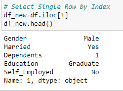

```python
# Code Explanation
# Therefore, print(df.iloc[1]) will print the values in the row at index position 1 from the DataFrame df.
```

###### 2.Select Multiple Rows & Columns by Index

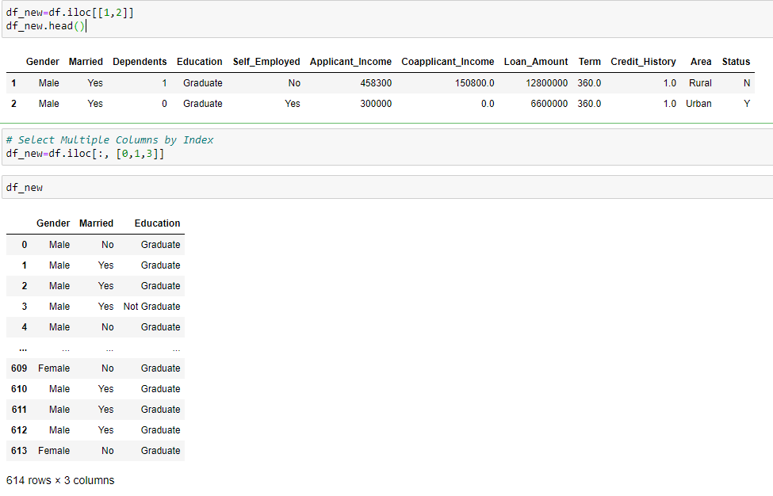

```python
# In summary, this code creates a new DataFrame df_new containing specific columns from the original DataFrame df based on their integer positions.
```

###### 3.Select Rows or Columns by Index Range

By using iloc[], you can also select rows and columns by range. For example all items between two rows/columns. all items starting from e.t.c. The below example selects rows in between 0 and 4 row indices.

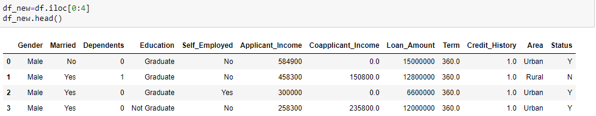

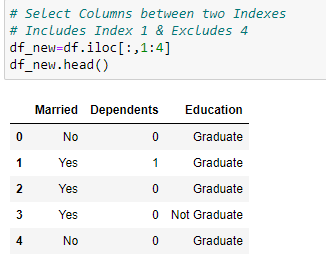

###### 4. Select Alternate Rows or Columns

Similarly, by using ranges you can also select every alternate row from DataFrame.

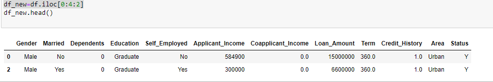

```python
# The code df_new = df.iloc[0:4:2] creates a new DataFrame df_new by selecting a subset of rows from the original DataFrame df. The rows selected include every second row starting from index position 0 up to, but not including, index position 4.

# Here's a breakdown of the code:

# df refers to the original DataFrame object.
# iloc is a function used to access a group of rows and columns by integer-based indexing. In this case, df.iloc[0:4:2] is used to select rows with index positions 0, 2.
# The selected rows are then assigned to a new DataFrame called df_new.
# Therefore, df_new will contain the rows with index positions 0 and 2 from the original DataFrame df. The 0:4:2 notation specifies the range of rows to be selected, with a step size of 2, meaning every second row will be included.

# In summary, the code df_new = df.iloc[0:4:2] creates a new DataFrame df_new by selecting every second row from index position 0 to index position 4 (excluding 4) from the original DataFrame df
```

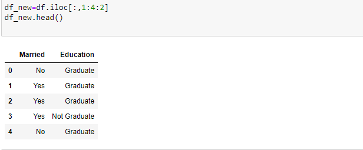

```python
#Code Explanation
# The code df.iloc[:, 1:4:2] selects a subset of columns from the DataFrame df using integer-based indexing. It includes columns starting from index position 1 up to, but not including, index position 4, with a step size of 2.
# Here's a breakdown of the code:

# df refers to the DataFrame object.
# iloc is a function used to access a group of rows and columns by integer-based indexing.
# : before the comma represents all rows in the DataFrame.
# 1:4:2 indicates the range of columns to be selected. It starts at index position 1, goes up to, but excludes, index position 4, and selects every second column with a step size of 2.
# Therefore, df.iloc[:, 1:4:2] selects columns at index positions 1 and 3 (if they exist) from the DataFrame df and returns a new DataFrame with those columns.

# In summary, the code df.iloc[:, 1:4:2] selects specific columns based on their integer positions from the DataFrame df and returns a new DataFrame with the selected columns.
```

###### 5.Using Conditions with iloc[]

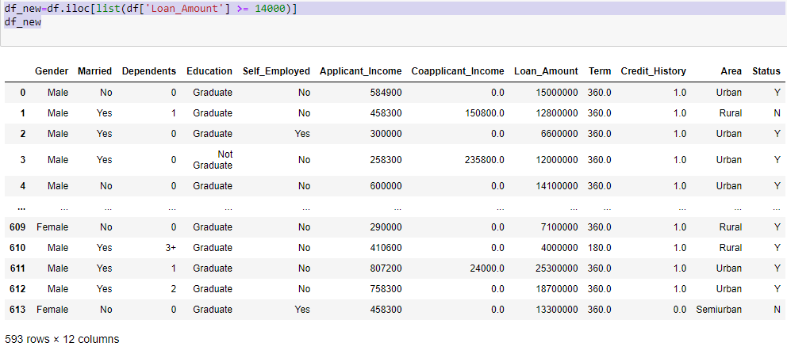

```python
# #code Explanation

# The code df_new = df.iloc[list(df['Loan_Amount'] >= 14000)] filters the rows of the DataFrame df based on a condition and creates a new DataFrame df_new with the selected rows.
# Here's a summary of the code:

# The original DataFrame df is being used.
# The condition df['Loan_Amount'] >= 14000 checks whether the values in the 'Loan_Amount' column are greater than or equal to 14000, resulting in a Boolean Series.
# list(df['Loan_Amount'] >= 14000) converts the Boolean Series into a list.
# df.iloc[list(df['Loan_Amount'] >= 14000)] uses the Boolean list as a filter to select only the rows where the condition is True. It retrieves the rows that satisfy the condition.
# The selected rows are then assigned to a new DataFrame called df_new.
# In summary, the code filters the DataFrame df based on a condition where the 'Loan_Amount' column is greater than or equal to 14000, and assigns the resulting rows to df_new.
```

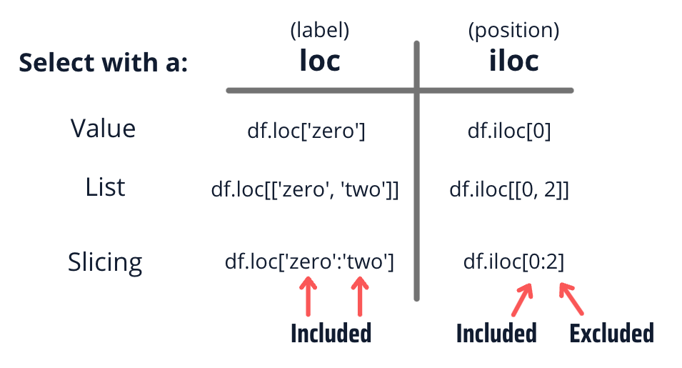

#### 3.Summary Functions and Maps

###### 1.describe()

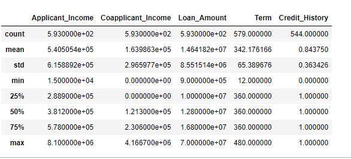

The describe() method returns description of the data in the DataFrame.

If the DataFrame contains numerical data, the description contains these information for each column:

count - The number of not-empty values. mean - The average (mean) value. std - The standard deviation.

min - the minimum value.

25% - The 25% percentile*.

50% - The 50% percentile*.

75% - The 75% percentile*.

max - the maximum value.

*Percentile meaning: how many of the values are less than the given percentile

###### 2.mean()

Pandas dataframe.mean() function returns the mean of the values for the requested axis. If the method is applied on a pandas series object, then the method returns a scalar value which is the mean value of all the observations in the Pandas Dataframe. If the method is applied on a Pandas Dataframe object, then the method returns a Pandas series object which contains the mean of the values over the specified axis.

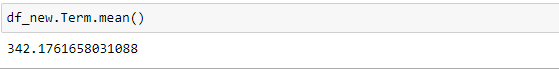

In above the column Term has mean of 342.176

###### 2.unique()

The unique function in pandas is used to find the unique values from a series.

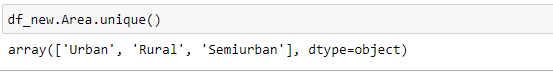

In above the column Area has 3 unique value

###### 3.value_counts()

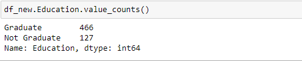

The value_counts() function in pandas returns a series that contains the number of unique values. A series is a one-dimensional array.